# Exploring word segmentation performance

Alejandrina Cristia

1/4/2018

## Read in data

First we read in the performance results

```r
results=dir(resfol,pattern="eval")
allres=NULL
for(thisres in results){
  test=scan(paste0(resfol,thisres),what="char")
  if(length(test)>0){
    read.table(paste0(resfol,thisres))->x
    clean_name=gsub("-tags.*","",thisres)
    unit=gsub(".*txt_","",thisres)
    unit=gsub("\\..*","",unit)
    algo=gsub(".eval.*","",thisres)
    algo=gsub(paste0(".*",unit,"."),"",algo)
    allres=rbind(allres,cbind(t(as.numeric(as.character(x[,-1]))),thisres,clean_name,algo,unit))
  }
}
colnames(allres)[1:dim(x)[1]]<-c(as.character(x[,1]))
write.table(allres,"derived/results.txt",quote=F,sep="\t")
```

Next we read the corpus characteristics descriptions and combine them with the above.

```r
read.table("derived/results.txt",header=T)->allres

library(jsonlite)
statsres=dir(resfol,pattern="stats")
allstats=NULL
for(thisstat in statsres){
  fromJSON(paste0(resfol,thisstat), flatten=TRUE)->x
  clean_name=gsub("-tags.*","",thisstat)
  nphone_tokens=x$phones$tokens
  nphone_types=x$phones$types
  nsyllable_tokens=x$syllables$tokens
  nsyllable_types=x$syllables$types
  nwords_tokens=x$words$tokens
  nwords_types=x$words$types
  nword_hapax=x$words$hapaxes
  mattr=x$corpus$mattr
  entropy=x$corpus$entropy
  nutts_single_word=x$corpus$nutts_single_word
  nutts=x$corpus$nutts
  allstats=rbind(allstats,cbind(clean_name,nphone_tokens,nphone_types,
                                        nsyllable_tokens,nsyllable_types,
                                nwords_tokens,nwords_types,
                                nword_hapax,mattr,
                                entropy,
                                nutts_single_word,nutts))
}

write.table(allstats,"derived/stats.txt",quote=F,sep="\t")
read.table("derived/stats.txt",header=T)->allstats #this inelegant write-out-read-in so that all cols are numeric
#calculate some proportions to capture tendency to have single-word utterances and to have words that are not repeated controlling to a certain extent for corpus size
allstats$prop_swu=allstats$nutts_single_word/allstats$nutts
allstats$prop_hap=allstats$nword_hapax/allstats$nwords_types
allstats$avg_ph_w=allstats$nphone_tokens/allstats$nwords_tokens
allstats$avg_syl_w=allstats$nsyllable_tokens/allstats$nwords_tokens
allstats$avg_w_utt=allstats$nwords_tokens/allstats$nutts
write.table(allstats,"derived/stats.txt",quote=F,sep="\t")


merge(allres,allstats,by="clean_name")->allres_stat
write.table(allres_stat,"derived/all.txt",quote=F,sep="\t")
```

## Preliminary descriptions

### Stats

```r
read.table("derived/stats.txt",header=T)->allstats
colSums(allstats[,grep("tokens",colnames(allstats))])
```

```
##    nphone_tokens nsyllable_tokens    nwords_tokens
##           848278           339002           275301
```

```r
sum(allstats$nutts)
```

```
## [1] 51820
```

```r
tab=round(cbind(apply(allstats[,-1],2,mean),
apply(allstats[,-1],2,sd)),4)
colnames(tab)<-c("Mean","SD")
rownames(tab)<-gsub("_"," ",rownames(tab))
rownames(tab)<-gsub("^n","N ",rownames(tab))
write.table(tab,"derived/stats_tab.txt",eol="\\\\\n",sep=" & ",quote=F)
```

### Results

```r
read.table("derived/all.txt",header=T)->res


summary(res)
```

```
##    clean_name   token_precision    token_recall      token_fscore
##  eth01  :  16   Min.   :0.01138   Min.   :0.00943   Min.   :0.01660
##  eth02  :  16   1st Qu.:0.17730   1st Qu.:0.09392   1st Qu.:0.08427
##  eth04  :  16   Median :0.40820   Median :0.30700   Median :0.34590
##  eth17  :  16   Mean   :0.40781   Mean   :0.37485   Mean   :0.37457
##  eth21  :  16   3rd Qu.:0.65250   3rd Qu.:0.66340   3rd Qu.:0.64470
##  eth24  :  16   Max.   :0.85970   Max.   :0.86050   Max.   :0.85520
##  (Other):1085
##  type_precision     type_recall        type_fscore
##  Min.   :0.03727   Min.   :0.002901   Min.   :0.005587
##  1st Qu.:0.12080   1st Qu.:0.122500   1st Qu.:0.124900
##  Median :0.21920   Median :0.374400   Median :0.274300
##  Mean   :0.29232   Mean   :0.355146   Mean   :0.310475
##  3rd Qu.:0.45880   3rd Qu.:0.558100   3rd Qu.:0.506000
##  Max.   :0.75530   Max.   :0.819200   Max.   :0.770300
##
##  boundary_all_precision boundary_all_recall boundary_all_fscore
##  Min.   :0.3330         Min.   :0.2295      Min.   :0.3734
##  1st Qu.:0.7337         1st Qu.:0.5596      1st Qu.:0.5373
##  Median :0.8996         Median :0.7715      Median :0.7335
##  Mean   :0.8274         Mean   :0.7145      Mean   :0.7164
##  3rd Qu.:0.9665         3rd Qu.:0.9349      3rd Qu.:0.8834
##  Max.   :1.0000         Max.   :1.0000      Max.   :0.9549
##
##  boundary_noedge_precision boundary_noedge_recall boundary_noedge_fscore
##  Min.   :0.2372            Min.   :0.0000         Min.   :0.0000
##  1st Qu.:0.5842            1st Qu.:0.3618         1st Qu.:0.3630
##  Median :0.7905            Median :0.6562         Median :0.5893
##  Mean   :0.7328            Mean   :0.5797         Mean   :0.5412
##  3rd Qu.:0.9109            3rd Qu.:0.9039         3rd Qu.:0.8247
##  Max.   :1.0000            Max.   :1.0000         Max.   :0.9343
##  NA's   :148
##                                      thisres             algo
##  eth01-tags.txt_phone.AGu.eval.txt       :   1   baseline00:148
##  eth01-tags.txt_phone.baseline00.eval.txt:   1   baseline05:148
##  eth01-tags.txt_phone.baseline05.eval.txt:   1   baseline10:148
##  eth01-tags.txt_phone.baseline10.eval.txt:   1   puddle    :148
##  eth01-tags.txt_phone.dibs_b.eval.txt    :   1   tpabs     :148
##  eth01-tags.txt_phone.puddle.eval.txt    :   1   tprel     :148
##  (Other)                                 :1175   (Other)   :293
```

[output cut: 25 more lines]

```
##  Min.   :0.06918   Min.   :0.2757   Min.   :2.936   Min.   :1.182
##  1st Qu.:0.11275   1st Qu.:0.4079   1st Qu.:3.017   1st Qu.:1.213
##  Median :0.12978   Median :0.4329   Median :3.062   Median :1.223
##  Mean   :0.14339   Mean   :0.4321   Mean   :3.075   Mean   :1.230
##  3rd Qu.:0.16441   3rd Qu.:0.4495   3rd Qu.:3.119   3rd Qu.:1.248
##  Max.   :0.31137   Max.   :0.5103   Max.   :3.294   Max.   :1.314
##
##    avg_w_utt
##  Min.   :3.243
##  1st Qu.:4.865
##  Median :5.347
##  Mean   :5.375
##  3rd Qu.:5.897
##  Max.   :7.713
##
```

```r
dim(res)
```

```
## [1] 1181   32
```

Checking for whether different outcomes are independent.

```r
subselcol=c("token_fscore","type_fscore","boundary_all_fscore")
sublabs=gsub("_","\n",subselcol)
sublabs=gsub("fs","F-s",sublabs)
pchs=c(3,15:18,0,7)


report_algos=c("ag","baseline00", "baseline05", "baseline10", "dibs_b", "puddle", "tpabs", "tprel")
if(mean(levels(as.factor(res$algo)) %in% report_algos)==1 & mean(report_algos  %in%  levels(as.factor(res$algo)))==1) mycols=c("darkgray","gray","lightgray","darkgreen","red","lightblue","darkblue") else mycols=brewer.pal(length(levels(as.factor(res$algo))), "BrBG")


pdf("derived/out.pdf")
pairs(res[,subselcol],col =  mycols[as.numeric(as.factor(res$algo))],xlim=range(res[,subselcol]),ylim=range(res[,subselcol]), pch=ifelse(res$unit=="phone",20,3),labels=sublabs)
dev.off()
```

```r
cor(res[,subselcol],method="p")
```

```
##                     token_fscore type_fscore boundary_all_fscore
## token_fscore           1.0000000   0.9750559           0.9703865
## type_fscore            0.9750559   1.0000000           0.9526761
## boundary_all_fscore    0.9703865   0.9526761           1.0000000
```

```r
cor(res[,subselcol],method="s")
```

```
##                     token_fscore type_fscore boundary_all_fscore
## token_fscore           1.0000000   0.9757113           0.9666808
## type_fscore            0.9757113   1.0000000           0.9665021
## boundary_all_fscore    0.9666808   0.9665021           1.0000000
```

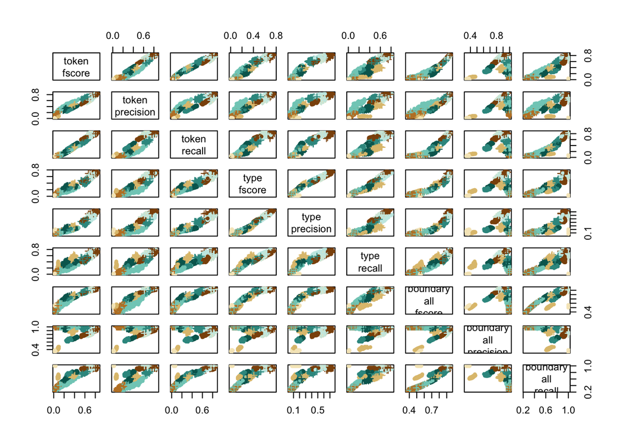

```r
#par(mfrow=c(1,3))
for(thisout in c("token_","type_","boundary_")){
  subselcol=colnames(res)[grep(thisout,colnames(res))]
  subselcol=subselcol[grep("noedge",subselcol,invert=T)]
  sublabs=gsub("_","\n",subselcol)
  sublabs=gsub("fs","F-s",sublabs)
  pdf(paste0("derived/out_",thisout,".pdf"),width=3,height=3)
  pairs(res[,subselcol],col =  mycols[as.numeric(as.factor(res$algo))],xlim=range(res[,subselcol]),ylim=range(res[,subselcol]), pch=ifelse(res$unit=="phone",20,3),labels=sublabs)
  dev.off()
}



selcol=c("token_fscore","token_precision","token_recall","type_fscore","type_precision","type_recall","boundary_all_fscore","boundary_all_precision","boundary_all_recall")
labs=gsub("_","\n",selcol)

pairs(res[,selcol],col =  mycols[as.numeric(as.factor(res$algo))], pch=ifelse(res$unit=="phone",20,3),labels=labs)
```

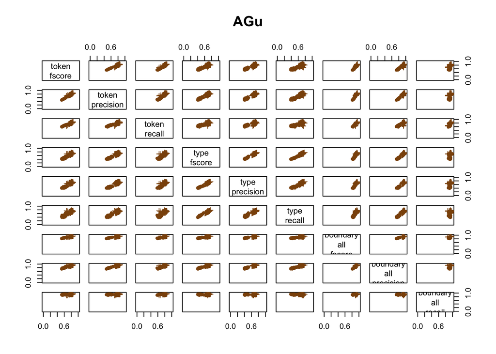

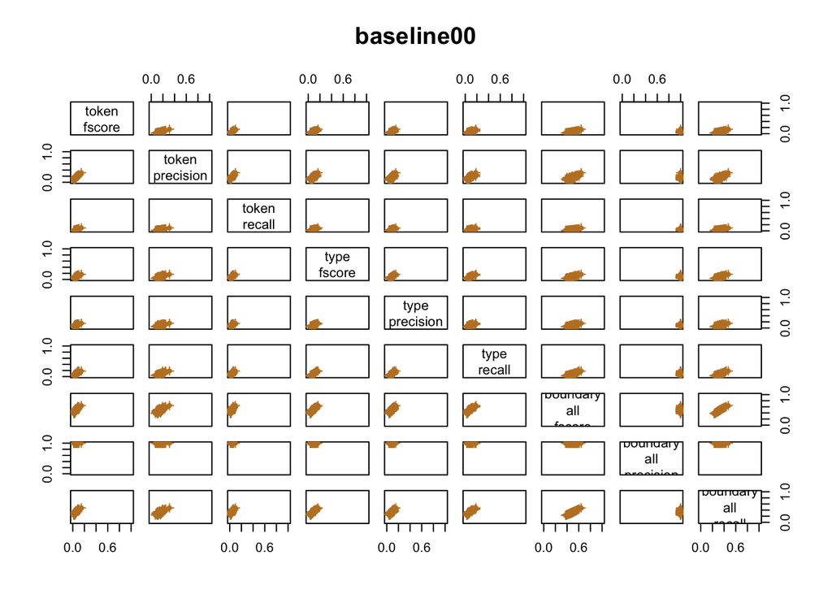

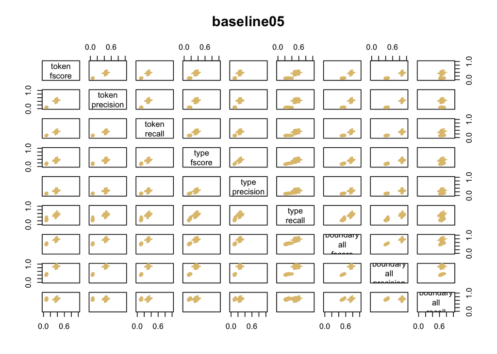

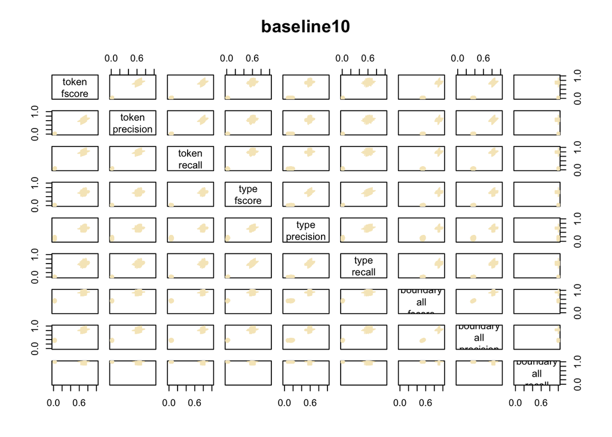

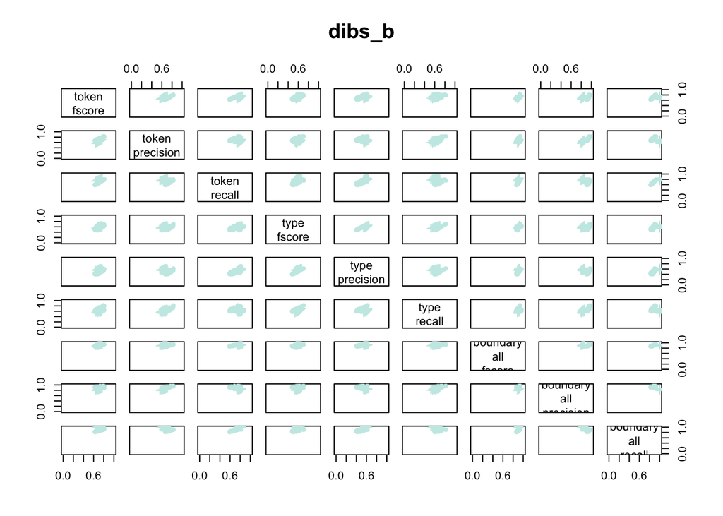

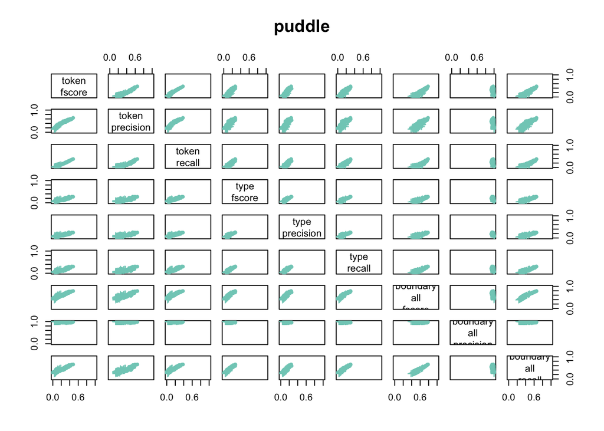

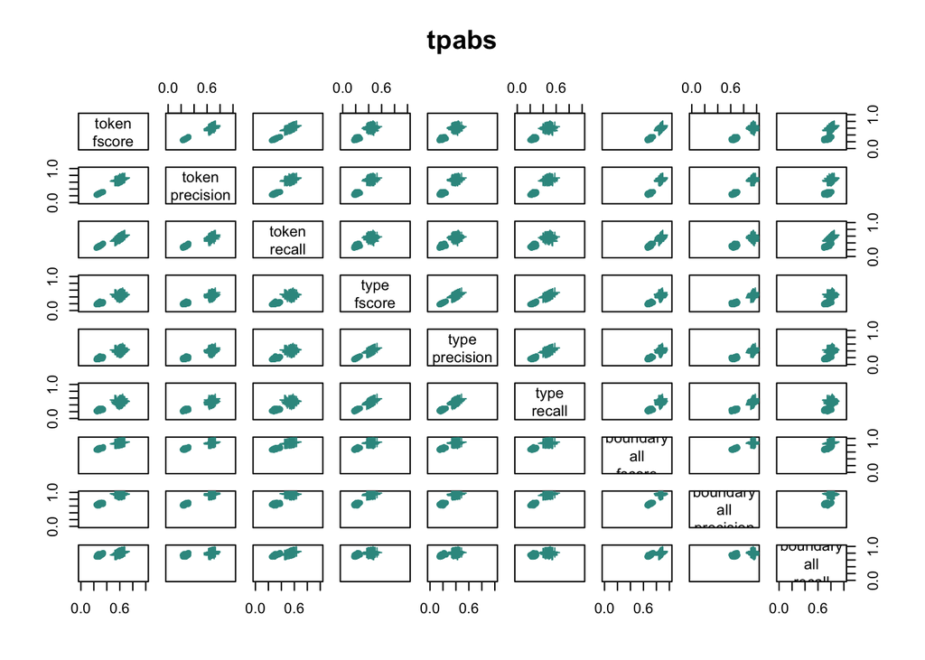

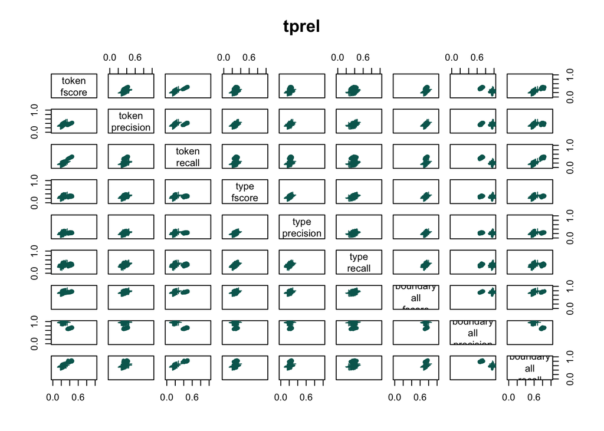

```r
for(i in 1:length(levels(res$algo))){
  thisalgo=levels(res$algo)[i]
  pairs(res[res$algo==thisalgo,selcol],col = mycols[i], pch=ifelse(res$unit[res$algo==thisalgo]=="phone",20,3),labels=labs,main=thisalgo,
      xlim=range(res[,selcol]),ylim=range(res[,selcol]))

}
```

```r
cor(res[,selcol],method="p")
```

```
##                        token_fscore token_precision token_recall
## token_fscore              1.0000000       0.9626117    0.9874000
## token_precision           0.9626117       1.0000000    0.9118427
## token_recall              0.9874000       0.9118427    1.0000000
## type_fscore               0.9750559       0.9310985    0.9655101
## type_precision            0.9567862       0.8956116    0.9630332
## type_recall               0.9316202       0.8932634    0.9092220
## boundary_all_fscore       0.9703865       0.9350224    0.9502874
## boundary_all_precision    0.2327649       0.4317375    0.1358189
## boundary_all_recall       0.7187438       0.5566896    0.7718825
##                        type_fscore type_precision type_recall
## token_fscore             0.9750559      0.9567862   0.9316202
## token_precision          0.9310985      0.8956116   0.8932634
## token_recall             0.9655101      0.9630332   0.9092220
## type_fscore              1.0000000      0.9752626   0.9682571
## type_precision           0.9752626      1.0000000   0.9012605
## type_recall              0.9682571      0.9012605   1.0000000
## boundary_all_fscore      0.9526761      0.9232680   0.9369732
## boundary_all_precision   0.2368546      0.1674922   0.1965080
## boundary_all_recall      0.6953009      0.7606554   0.6636461
##                        boundary_all_fscore boundary_all_precision
## token_fscore                     0.9703865              0.2327649
## token_precision                  0.9350224              0.4317375
## token_recall                     0.9502874              0.1358189
## type_fscore                      0.9526761              0.2368546
## type_precision                   0.9232680              0.1674922
## type_recall                      0.9369732              0.1965080
## boundary_all_fscore              1.0000000              0.1907876
## boundary_all_precision           0.1907876              1.0000000
## boundary_all_recall              0.7543195             -0.4460988
##                        boundary_all_recall
## token_fscore                     0.7187438
## token_precision                  0.5566896
## token_recall                     0.7718825
## type_fscore                      0.6953009
## type_precision                   0.7606554
## type_recall                      0.6636461
## boundary_all_fscore              0.7543195
## boundary_all_precision          -0.4460988
## boundary_all_recall              1.0000000
```

```r
#
```

## Effects of unit and algo

Fit a regression with these two basic predictors.

```r
minfit=lm(res$token_fscore~res$algo*res$unit + (1/res$clean_name))
summary(minfit)
```

```
##
## Call:
## lm(formula = res$token_fscore ~ res$algo * res$unit + (1/res$clean_name))
##
## Residuals:
##       Min        1Q    Median        3Q       Max
## -0.189021 -0.015027 -0.001238  0.014278  0.202009
##
## Coefficients:
##                                      Estimate Std. Error t value Pr(>|t|)
## (Intercept)                          0.604821   0.003963  152.62   <2e-16
## res$algobaseline00                  -0.557264   0.005586  -99.77   <2e-16
## res$algobaseline05                  -0.518690   0.005586  -92.86   <2e-16
## res$algobaseline10                  -0.578218   0.005586 -103.52   <2e-16
## res$algodibs_b                       0.090929   0.005605   16.22   <2e-16
## res$algopuddle                      -0.327129   0.005586  -58.57   <2e-16
## res$algotpabs                       -0.321903   0.005586  -57.63   <2e-16
## res$algotprel                       -0.188977   0.005586  -33.83   <2e-16
## res$unitsyllable                     0.191830   0.005605   34.23   <2e-16
## res$algobaseline00:res$unitsyllable -0.191830   0.007899  -24.29   <2e-16
## res$algobaseline05:res$unitsyllable  0.084677   0.007899   10.72   <2e-16
## res$algobaseline10:res$unitsyllable  0.502845   0.007899   63.66   <2e-16
## res$algodibs_b:res$unitsyllable     -0.164758   0.007913  -20.82   <2e-16
## res$algopuddle:res$unitsyllable     -0.395818   0.007899  -50.11   <2e-16
## res$algotpabs:res$unitsyllable       0.136156   0.007899   17.24   <2e-16
## res$algotprel:res$unitsyllable      -0.374257   0.007899  -47.38   <2e-16
##
## (Intercept)                         ***
## res$algobaseline00                  ***
## res$algobaseline05                  ***
## res$algobaseline10                  ***
## res$algodibs_b                      ***
## res$algopuddle                      ***
## res$algotpabs                       ***
## res$algotprel                       ***
## res$unitsyllable                    ***
## res$algobaseline00:res$unitsyllable ***
## res$algobaseline05:res$unitsyllable ***
## res$algobaseline10:res$unitsyllable ***
## res$algodibs_b:res$unitsyllable     ***
## res$algopuddle:res$unitsyllable     ***
## res$algotpabs:res$unitsyllable      ***
## res$algotprel:res$unitsyllable      ***
## ---
## Signif. codes:  0 '***' 0.001 '**' 0.01 '*' 0.05 '.' 0.1 ' ' 1
##
## Residual standard error: 0.03386 on 1165 degrees of freedom
## Multiple R-squared:  0.9849, Adjusted R-squared:  0.9847
## F-statistic:  5057 on 15 and 1165 DF,  p-value: < 2.2e-16
```

```r
library(car)
Anova(minfit)
```

```
## Anova Table (Type II tests)
##
## Response: res$token_fscore
##                   Sum Sq   Df F value    Pr(>F)
## res$algo          58.125    7  7242.4 < 2.2e-16 ***
## res$unit           5.909    1  5153.8 < 2.2e-16 ***
## res$algo:res$unit 22.896    7  2852.9 < 2.2e-16 ***
## Residuals          1.336 1165
## ---
## Signif. codes:  0 '***' 0.001 '**' 0.01 '*' 0.05 '.' 0.1 ' ' 1
```

```r
mypos=jitter(as.numeric(res$algo)+ifelse(res$unit=="phone",-.25,+.25))
pdf("derived/ua.pdf",height=6,width=12)
plot(token_fscore~mypos,data=res,pch=ifelse(res$unit=="phone",20,3),xlab="Algorithm and unit",ylab="Token F-score",xaxt="n",col =  mycols[as.numeric(as.factor(res$algo))])
axis(side=1,at=1:length(levels(res$algo)),gsub("aseline","",levels(res$algo)),tick=F,line=1)
axis(side=1,at=c(1:length(levels(res$algo))-.25,1:length(levels(res$algo))+.25),c(rep("P",length(levels(res$algo))),rep("S",length(levels(res$algo)))),tick=F,line=-.25)
dev.off()
```

To be able to focus on other predictors, in some of the following analyses, we’ll use the residuals from above.

```r
res$res_ua<-residuals(minfit)
```

## Corpus size effects

Corpus size can be measured in number of phones, words, utterances. To decide which of the three we’ll use in further analyses, we inspect the proportion of variance explained by each.

```r
for(thispred in c("nphone_tokens","nsyllable_tokens","nwords_tokens","nutts")){
  myfit=lm(res$token_fscore~res$algo*res$unit*res[,thispred] + (1/res$clean_name))
  print(thispred)
  print(summary(myfit)$adj.r.squared)
}
```

```
## [1] "nphone_tokens"
## [1] 0.986334
## [1] "nsyllable_tokens"
## [1] 0.9863415
## [1] "nwords_tokens"
## [1] 0.98636
## [1] "nutts"
## [1] 0.9882466
```

The best is number of utterances. In the following graph, we show the (lack of) association between performance and corpus length for all algorithms except for PUDDLE-phone.

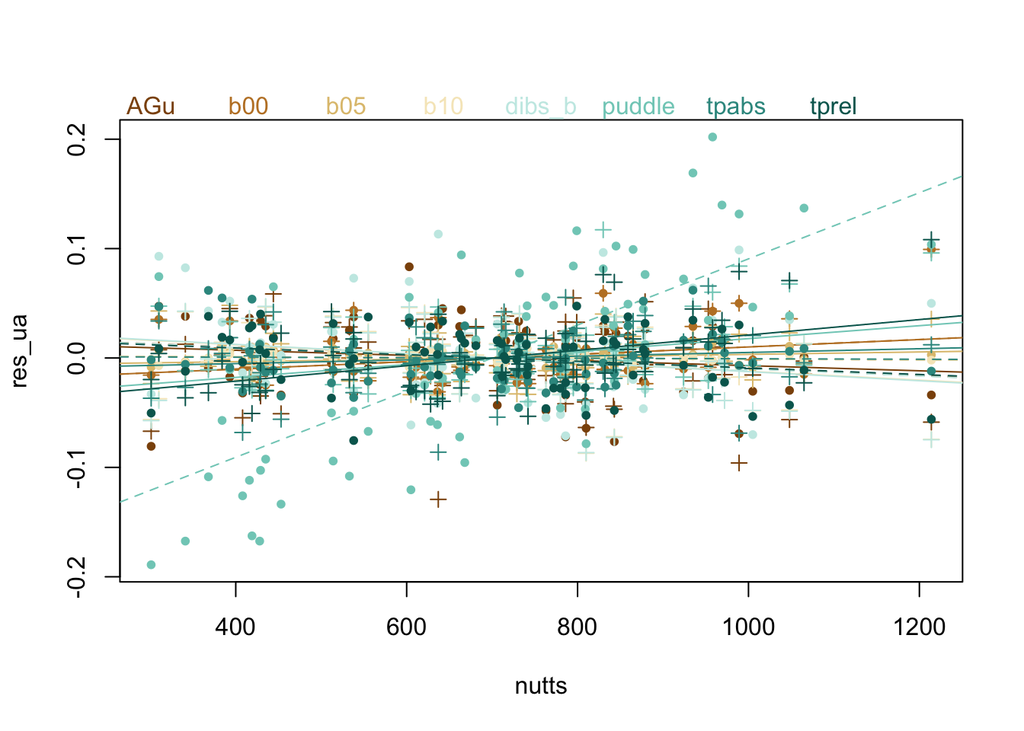

```r
#levels(res$algo)
#[1] "baseline00" "baseline05" "baseline10" "puddle"     "tpabs"      "tprel"
lims=range(res$nutts)
pos=seq(lims[1],lims[2],by=(lims[2]-lims[1])/length(levels(res$algo)))

plot(res_ua~nutts,data=res,type="n")
for(thisalgo in 1:length(levels(res$algo))) { points(res_ua~nutts,data=res,subset=c(algo==levels(res$algo)[thisalgo]),pch=ifelse(res$unit[res$algo==levels(res$algo)[thisalgo]]=="phone",20,3),col=mycols[thisalgo])
    abline(lm(res_ua~nutts + (1/clean_name),data=res,subset=c(res$algo==levels(res$algo)[thisalgo] & res$unit=="phone") ),col=mycols[thisalgo],lty=2)
  abline(lm(res_ua~nutts + (1/clean_name),data=res,subset=c(res$algo==levels(res$algo)[thisalgo] & res$unit!="phone") ),col=mycols[thisalgo],lty=1)
  mtext(text=gsub("aseline","",levels(res$algo)[thisalgo]),side=3,col=mycols[thisalgo],at=pos[thisalgo])
}
```

```r
pdf("derived/length.pdf",width=12,height=6)
plot(token_fscore~nutts,data=res,type="n",xlab="N utts",ylab="Token F-score")
for(thisalgo in 1:length(levels(res$algo))) { points(token_fscore~nutts,data=res,subset=c(algo==levels(res$algo)[thisalgo]),pch=ifelse(res$unit[res$algo==levels(res$algo)[thisalgo]]=="phone",20,3),col=mycols[thisalgo])
    abline(lm(token_fscore~nutts + (1/clean_name),data=res,subset=c(res$algo==levels(res$algo)[thisalgo] & res$unit=="phone") ),col=mycols[thisalgo],lty=2)
  abline(lm(token_fscore~nutts + (1/clean_name),data=res,subset=c(res$algo==levels(res$algo)[thisalgo] & res$unit!="phone") ),col=mycols[thisalgo],lty=1)
  #mtext(text=gsub("aseline","",levels(res$algo)[thisalgo]),side=3,col=mycols[thisalgo],at=pos[thisalgo])
}
dev.off()
```

```r
tab=NULL
for(thisalgo in 1:length(levels(res$algo))) {
  phonelm=summary(lm(token_fscore~nutts + (1/clean_name),data=res,subset=c(res$algo==levels(res$algo)[thisalgo] & res$unit=="phone")))
  syllm=summary(lm(token_fscore~nutts + (1/clean_name),data=res,subset=c(res$algo==levels(res$algo)[thisalgo] & res$unit!="phone")))
    print(phonelm)
    print(syllm)
    tab=rbind(tab,rbind(
      cbind(levels(res$algo)[thisalgo],"phone",phonelm$adj.r.squared,phonelm$coefficients[2],phonelm$coefficients[8]),
      cbind(levels(res$algo)[thisalgo],"syll",syllm$adj.r.squared,syllm$coefficients[2],syllm$coefficients[8])
      ))
}
```

```
##
## Call:
## lm(formula = token_fscore ~ nutts + (1/clean_name), data = res,
##     subset = c(res$algo == levels(res$algo)[thisalgo] & res$unit ==
##         "phone"))
##
## Residuals:
##       Min        1Q    Median        3Q       Max
## -0.093701 -0.018395  0.003357  0.025047  0.080185
##
## Coefficients:
##               Estimate Std. Error t value Pr(>|t|)
## (Intercept)  6.276e-01  1.342e-02  46.749   <2e-16 ***
## nutts       -3.240e-05  1.839e-05  -1.762   0.0824 .
## ---
## Signif. codes:  0 '***' 0.001 '**' 0.01 '*' 0.05 '.' 0.1 ' ' 1
##
## Residual standard error: 0.03164 on 71 degrees of freedom
## Multiple R-squared:  0.04189,    Adjusted R-squared:  0.0284
## F-statistic: 3.105 on 1 and 71 DF,  p-value: 0.08238
##
##
## Call:
## lm(formula = token_fscore ~ nutts + (1/clean_name), data = res,
##     subset = c(res$algo == levels(res$algo)[thisalgo] & res$unit !=
##         "phone"))
##
## Residuals:
##       Min        1Q    Median        3Q       Max
## -0.130768 -0.015468  0.005686  0.024666  0.057044
##
## Coefficients:
##               Estimate Std. Error t value Pr(>|t|)
## (Intercept)  8.131e-01  1.524e-02  53.355   <2e-16 ***
## nutts       -2.349e-05  2.088e-05  -1.125    0.264
## ---
## Signif. codes:  0 '***' 0.001 '**' 0.01 '*' 0.05 '.' 0.1 ' ' 1
##
## Residual standard error: 0.03592 on 71 degrees of freedom
## Multiple R-squared:  0.01751,    Adjusted R-squared:  0.003676
```

[output cut: 280 more lines]

```
##
## Residuals:
##       Min        1Q    Median        3Q       Max
## -0.056256 -0.016871 -0.006254  0.014135  0.071996
##
## Coefficients:
##              Estimate Std. Error t value Pr(>|t|)
## (Intercept) 1.841e-01  1.186e-02  15.522  < 2e-16 ***
## nutts       7.044e-05  1.628e-05   4.326 4.81e-05 ***
## ---
## Signif. codes:  0 '***' 0.001 '**' 0.01 '*' 0.05 '.' 0.1 ' ' 1
##
## Residual standard error: 0.02806 on 72 degrees of freedom
## Multiple R-squared:  0.2063, Adjusted R-squared:  0.1953
## F-statistic: 18.71 on 1 and 72 DF,  p-value: 4.808e-05
```

```r
colnames(tab)<-c("Algo","Unit","R2","B","p")
tab[,3]=round(as.numeric(as.character(tab[,3]))*100,1)
tab[,4]=round(as.numeric(as.character(tab[,4]))*10^4,3)
tab[,5]=round(as.numeric(as.character(tab[,5])),3)
tab[,1]=gsub("_b","",tab[,1])
tab[,5]<-ifelse(tab[,5]<0.05,paste0(tab[,5],"*"),tab[,5])
tab[tab[,5]=="0*",5]<-"<.001*"
write.table(tab,"derived/lng-ind-tab.txt",eol="\\\\\n",sep=" & ",quote=F,row.names = F)
```

## Further exploration of the role of corpus length

```r
library(jsonlite)
for(thisfol in dir(resfol_conc)){
  # dir(resfol_conc)[3]->thisfol
  thispath=paste0(resfol_conc,"/",thisfol,"/")
  leval=dir(path=thispath,pattern="eval")
  allres=NULL
  for(thisres in leval){
   # leval[1]->thisres
   test=scan(paste0(thispath,thisres),what="char")
    if(length(test)>0){
      read.table(paste0(thispath,thisres))->x
      x[,"V2"]<-as.numeric(as.character(x[,"V2"]))
      clean_name=gsub("_.*","",thisres)
      unit=gsub(".*phone.*","phone",gsub(".*syllable.*","syllable",thisres))
      algo=gsub("^[0-9]*_","",thisres)
      algo=gsub("dibsb","dibs_b",gsub("_","",gsub(fixed=T,".","",gsub(unit,"",gsub(".txt","",gsub(".eval","",algo))))))
      allres=rbind(allres,cbind(t(x[,-1]),thisfol,thisres,clean_name,algo,unit))
    }
  }
  colnames(allres)[1:dim(x)[1]]<-c(as.character(x[,1]))
  write.table(allres,paste0("derived/length_results_",thisfol,".txt"),quote=F,sep="\t")


  statsres=dir(path=thispath,pattern="stats")
  allstats=NULL
  for(thisstat in statsres){
    fromJSON(paste0(thispath,thisstat), flatten=TRUE)->x
    clean_name=gsub("_.*","",thisstat)
    nphone_tokens=x$phones$tokens
    nphone_types=x$phones$types
    nsyllable_tokens=x$syllables$tokens
    nsyllable_types=x$syllables$types
    nwords_tokens=x$words$tokens
    nwords_types=x$words$types

  #!! this is a patch, fix for the replication
    nword_hapax=x$corpus$nword_hapax
    if(is.null(nword_hapax))  nword_hapax=x$words$hapaxes
    mattr=x$corpus$mattr
    entropy=x$corpus$entropy
    nutts_single_word=x$corpus$nutts_single_word
    nutts=x$corpus$nutts
    allstats=rbind(allstats,cbind(clean_name,nphone_tokens,nphone_types,
                                  nsyllable_tokens,nsyllable_types,
                                  nwords_tokens,nwords_types,
                                  nword_hapax,mattr,
                                  entropy,
                                  nutts_single_word,nutts))
  }

  write.table(allstats,paste0("derived/length_stats_",thisfol,".txt"),quote=F,sep="\t")
  read.table(paste0("derived/length_stats_",thisfol,".txt"),header=T)->allstats #this inelegant write-out-read-in so that all cols are numeric
  #calculate some proportions to capture tendency to have single-word utterances and to have words that are not repeated controlling to a certain extent for corpus size
  allstats$prop_swu=allstats$nutts_single_word/allstats$nutts
  allstats$prop_hap=allstats$nword_hapax/allstats$nwords_types
  allstats$avg_ph_w=allstats$nphone_tokens/allstats$nwords_tokens
  allstats$avg_syl_w=allstats$nsyllable_tokens/allstats$nwords_tokens
  allstats$avg_w_utt=allstats$nwords_tokens/allstats$nutts
  write.table(allstats,paste0("derived/length_stats_",thisfol,".txt"),quote=F,sep="\t")

  merge(allres,allstats,by="clean_name")->allres_stat
  write.table(allres_stat,paste0("derived/length_all_",thisfol,".txt"),quote=F,sep="\t")
}

concats=dir(path="derived/",pattern="length_all_")
lng=NULL
for(thisconc in concats){
  read.table(paste0("derived/",thisconc),header=T)->temp
  lng=rbind(lng,cbind(temp,thisconc))
}
write.table(lng,"derived/length_allKids.txt",row.names=F,quote=F,sep="\t")
```

```r
read.table("derived/length_allKids.txt",header=T)->lng

summary(lng)
```

```
##    clean_name    token_precision    token_recall      token_fscore
##  Min.   : 1.00   Min.   :0.01138   Min.   :0.02181   Min.   :0.01720
##  1st Qu.: 4.00   1st Qu.:0.20200   1st Qu.:0.11210   1st Qu.:0.08987
##  Median : 9.00   Median :0.40930   Median :0.31390   Median :0.36430
##  Mean   :10.92   Mean   :0.40801   Mean   :0.37826   Mean   :0.37749
##  3rd Qu.:17.00   3rd Qu.:0.65200   3rd Qu.:0.63690   3rd Qu.:0.63940
##  Max.   :30.00   Max.   :0.82530   Max.   :0.82390   Max.   :0.80900
##
##  type_precision     type_recall        type_fscore
##  Min.   :0.03289   Min.   :0.002259   Min.   :0.004473
##  1st Qu.:0.09137   1st Qu.:0.173200   1st Qu.:0.102800
##  Median :0.19580   Median :0.367400   Median :0.241100
##  Mean   :0.25112   Mean   :0.351282   Mean   :0.265315
##  3rd Qu.:0.38470   3rd Qu.:0.522600   3rd Qu.:0.421500
##  Max.   :0.64400   Max.   :0.800700   Max.   :0.684700
##
##  boundary_all_precision boundary_all_recall boundary_all_fscore
##  Min.   :0.3525         Min.   :0.2952      Min.   :0.4558
##  1st Qu.:0.7156         1st Qu.:0.6207      1st Qu.:0.5584
##  Median :0.8590         Median :0.7970      Median :0.7537
##  Mean   :0.8188         Mean   :0.7330      Mean   :0.7288
##  3rd Qu.:0.9686         3rd Qu.:0.9302      3rd Qu.:0.8760
##  Max.   :1.0000         Max.   :1.0000      Max.   :0.9424
##
##  boundary_noedge_precision boundary_noedge_recall boundary_noedge_fscore
##  Min.   :0.2372            Min.   :0.0000         Min.   :0.0000
##  1st Qu.:0.5683            1st Qu.:0.4289         1st Qu.:0.3625
##  Median :0.7775            Median :0.6879         Median :0.6050
##  Mean   :0.7106            Mean   :0.5924         Mean   :0.5499
##  3rd Qu.:0.8889            3rd Qu.:0.8913         3rd Qu.:0.8143
##  Max.   :1.0000            Max.   :1.0000         Max.   :0.8971
##  NA's   :148
##        thisfol                           thisres             algo
##  eth_concat:315   1_phone_eval.AGu.txt       :   5   baseline00:148
##  lil_concat:180   1_phone_eval.dibs_b.txt    :   5   baseline05:148
##  nai_concat:441   1_phone.baseline00.eval.txt:   5   baseline10:148
##  vio_concat:120   1_phone.baseline05.eval.txt:   5   puddle    :148
##  wil_concat: 45   1_phone.baseline10.eval.txt:   5   tpabs     :148
##                   1_phone.puddle.eval.txt    :   5   tprel     :148
##                   (Other)                    :1071   (Other)   :213
```

[output cut: 25 more lines]

```
##  Min.   :0.1232   Min.   :0.2757   Min.   :2.951   Min.   :1.195
##  1st Qu.:0.1337   1st Qu.:0.3239   1st Qu.:3.049   1st Qu.:1.220
##  Median :0.1549   Median :0.3469   Median :3.068   Median :1.231
##  Mean   :0.1649   Mean   :0.3567   Mean   :3.075   Mean   :1.234
##  3rd Qu.:0.1887   3rd Qu.:0.3893   3rd Qu.:3.083   3rd Qu.:1.236
##  Max.   :0.3114   Max.   :0.4392   Max.   :3.224   Max.   :1.303
##
##    avg_w_utt                          thisconc
##  Min.   :3.243   length_all_eth_concat.txt:315
##  1st Qu.:4.514   length_all_lil_concat.txt:180
##  Median :4.865   length_all_nai_concat.txt:441
##  Mean   :4.886   length_all_vio_concat.txt:120
##  3rd Qu.:5.445   length_all_wil_concat.txt: 45
##  Max.   :5.775
##
```

```r
table(lng$thisconc,lng$unit,lng$algo)
```

```
## , ,  = AGu
##
##
##                             phone syllable
##   length_all_eth_concat.txt    21        0
##   length_all_lil_concat.txt    12        0
##   length_all_nai_concat.txt    22        0
##   length_all_vio_concat.txt     8        0
##   length_all_wil_concat.txt     3        0
##
## , ,  = baseline00
##
##
##                             phone syllable
##   length_all_eth_concat.txt    21       21
##   length_all_lil_concat.txt    12       12
##   length_all_nai_concat.txt    30       30
##   length_all_vio_concat.txt     8        8
##   length_all_wil_concat.txt     3        3
##
## , ,  = baseline05
##
##
##                             phone syllable
##   length_all_eth_concat.txt    21       21
##   length_all_lil_concat.txt    12       12
##   length_all_nai_concat.txt    30       30
##   length_all_vio_concat.txt     8        8
##   length_all_wil_concat.txt     3        3
##
## , ,  = baseline10
##
##
##                             phone syllable
##   length_all_eth_concat.txt    21       21
##   length_all_lil_concat.txt    12       12
##   length_all_nai_concat.txt    30       30
##   length_all_vio_concat.txt     8        8
##   length_all_wil_concat.txt     3        3
##
```

[output cut: 24 more lines]

```
##   length_all_eth_concat.txt    21       21
##   length_all_lil_concat.txt    12       12
##   length_all_nai_concat.txt    30       30
##   length_all_vio_concat.txt     8        8
##   length_all_wil_concat.txt     3        3
##
## , ,  = tprel
##
##
##                             phone syllable
##   length_all_eth_concat.txt    21       21
##   length_all_lil_concat.txt    12       12
##   length_all_nai_concat.txt    30       30
##   length_all_vio_concat.txt     8        8
##   length_all_wil_concat.txt     3        3
```

```r
minfit=lm(token_fscore~algo*unit + (1/thisconc),data=lng) #
summary(minfit)
```

```
##
## Call:
## lm(formula = token_fscore ~ algo * unit + (1/thisconc), data = lng)
##
## Residuals:
##      Min       1Q   Median       3Q      Max
## -0.43370 -0.01023  0.00133  0.01280  0.14156
##
## Coefficients: (1 not defined because of singularities)
##                              Estimate Std. Error  t value Pr(>|t|)
## (Intercept)                  0.616683   0.004109  150.066   <2e-16 ***
## algobaseline00              -0.558762   0.005652  -98.855   <2e-16 ***
## algobaseline05              -0.529495   0.005652  -93.677   <2e-16 ***
## algobaseline10              -0.591157   0.005652 -104.586   <2e-16 ***
## algodibs_b                   0.050757   0.005652    8.980   <2e-16 ***
## algopuddle                  -0.007987   0.005652   -1.413    0.158
## algotpabs                   -0.343291   0.005652  -60.734   <2e-16 ***
## algotprel                   -0.191509   0.005652  -33.881   <2e-16 ***
## unitsyllable                -0.145647   0.005488  -26.537   <2e-16 ***
## algobaseline00:unitsyllable  0.145647   0.007762   18.764   <2e-16 ***
## algobaseline05:unitsyllable  0.428968   0.007762   55.266   <2e-16 ***
## algobaseline10:unitsyllable  0.835432   0.007762  107.633   <2e-16 ***
## algodibs_b:unitsyllable      0.195479   0.007775   25.142   <2e-16 ***
## algopuddle:unitsyllable     -0.303394   0.007762  -39.088   <2e-16 ***
## algotpabs:unitsyllable       0.502835   0.007762   64.783   <2e-16 ***
## algotprel:unitsyllable             NA         NA       NA       NA
## ---
## Signif. codes:  0 '***' 0.001 '**' 0.01 '*' 0.05 '.' 0.1 ' ' 1
##
## Residual standard error: 0.03339 on 1086 degrees of freedom
## Multiple R-squared:  0.9833, Adjusted R-squared:  0.9831
## F-statistic:  4568 on 14 and 1086 DF,  p-value: < 2.2e-16
```

```r
for(thispred in c("nwords_tokens","nphone_tokens","nutts")){
  myfit=lm(token_fscore~algo*unit*lng[,thispred] + (1/thisconc) ,data=lng)
  print(thispred)
  print(summary(myfit)$adj.r.squared)
}
```

```
## [1] "nwords_tokens"
## [1] 0.9874538
## [1] "nphone_tokens"
## [1] 0.9874483
## [1] "nutts"
## [1] 0.9878297
```

```r
pdf("derived/multi.pdf")
plot(token_fscore~nutts,data=lng,type="n",xlab="N word tokens",ylab="Token F-score")
for(thisscore in 0:10) lines(c(0,10^6),c(thisscore/10,thisscore/10),lty=3,col="gray")
for(thisalgo in 1:length(levels(lng$algo))) {
  points(token_fscore~nutts,data=lng,subset=c(algo==levels(lng$algo)[thisalgo]),
         pch=ifelse(lng$unit[lng$algo==levels(lng$algo)[thisalgo]]=="phone",20,3),
         col=mycols[thisalgo] )
}
names(mycols)<-levels(lng$algo)

lng$kind=paste(lng$thisconc,lng$unit,lng$algo)
for(i in 2:max(lng$clean_name) ){
  for(thiskind in levels(as.factor(lng$kind))){
    origin=lng[lng$kind==thiskind & lng$clean_name==(i-1),c("nutts","token_fscore")]
    end=lng[lng$kind==thiskind & lng$clean_name==(i),c("nutts","token_fscore")]
    lines(c(origin$nutts,end$nutts),c(origin$token_fscore,end$token_fscore),lwd=1,
          col=mycols[names(mycols)==strsplit(thiskind," ")[[1]][3]])
  }
}
dev.off()
```

### Investigate length with independent transcripts

```r
ind=NULL
for(thisc in levels(lng$thisconc)){
  subset(lng, thisconc==thisc)-> xx
  ind=rbind(ind,subset(xx, clean_name==max(xx$clean_name)))
}

  simple=lm(token_fscore~algo*unit + (1/thisconc) ,data=ind)
  print(summary(simple)$adj.r.squared)
```

```
## [1] 0.992401
```

```r
  print(summary(simple))
```

```
##
## Call:
## lm(formula = token_fscore ~ algo * unit + (1/thisconc), data = ind)
##
## Residuals:
##       Min        1Q    Median        3Q       Max
## -0.046940 -0.013070 -0.000347  0.009715  0.061960
##
## Coefficients: (1 not defined because of singularities)
##                             Estimate Std. Error t value Pr(>|t|)
## (Intercept)                  0.61725    0.01135  54.367  < 2e-16 ***
## algobaseline00              -0.56461    0.01523 -37.066  < 2e-16 ***
## algobaseline05              -0.53071    0.01523 -34.841  < 2e-16 ***
## algobaseline10              -0.59170    0.01523 -38.845  < 2e-16 ***
## algodibs_b                   0.03495    0.01523   2.294   0.0253 *
## algopuddle                   0.01059    0.01523   0.695   0.4896
## algotpabs                   -0.35703    0.01523 -23.439  < 2e-16 ***
## algotprel                   -0.19033    0.01523 -12.495  < 2e-16 ***
## unitsyllable                -0.15964    0.01436 -11.116 4.21e-16 ***
## algobaseline00:unitsyllable  0.15964    0.02031   7.860 9.43e-11 ***
## algobaseline05:unitsyllable  0.44212    0.02031  21.769  < 2e-16 ***
## algobaseline10:unitsyllable  0.85789    0.02031  42.240  < 2e-16 ***
## algodibs_b:unitsyllable      0.23270    0.02031  11.458  < 2e-16 ***
## algopuddle:unitsyllable     -0.30146    0.02031 -14.843  < 2e-16 ***
## algotpabs:unitsyllable       0.53610    0.02031  26.396  < 2e-16 ***
## algotprel:unitsyllable            NA         NA      NA       NA
## ---
## Signif. codes:  0 '***' 0.001 '**' 0.01 '*' 0.05 '.' 0.1 ' ' 1
##
## Residual standard error: 0.02271 on 59 degrees of freedom
## Multiple R-squared:  0.9939, Adjusted R-squared:  0.9924
## F-statistic:   682 on 14 and 59 DF,  p-value: < 2.2e-16
```

```r
for(thispred in c("nwords_tokens")){ #"nutts","nphone_tokens",
  myfit=lm(token_fscore~algo*unit*ind[,thispred] + (1/thisconc) ,data=ind)
  print(thispred)
  print(summary(myfit)$adj.r.squared)
  print(summary(myfit))
  anova(simple,myfit)
}
```

```
## [1] "nwords_tokens"
## [1] 0.9938565
##
## Call:
## lm(formula = token_fscore ~ algo * unit * ind[, thispred] + (1/thisconc),
##     data = ind)
##
## Residuals:
##       Min        1Q    Median        3Q       Max
## -0.040642 -0.007290 -0.000180  0.008944  0.045848
##
## Coefficients: (2 not defined because of singularities)
##                                               Estimate Std. Error t value
## (Intercept)                                  6.329e-01  1.844e-02  34.325
## algobaseline00                              -5.682e-01  2.420e-02 -23.477
## algobaseline05                              -5.445e-01  2.420e-02 -22.498
## algobaseline10                              -6.094e-01  2.420e-02 -25.180
## algodibs_b                                   5.486e-02  2.420e-02   2.267
## algopuddle                                  -2.238e-02  2.420e-02  -0.925
## algotpabs                                   -3.672e-01  2.420e-02 -15.172
## algotprel                                   -2.058e-01  2.420e-02  -8.502
## unitsyllable                                -1.741e-01  2.217e-02  -7.854
## ind[, thispred]                             -4.004e-07  3.924e-07  -1.020
## algobaseline00:unitsyllable                  1.741e-01  3.135e-02   5.554
## algobaseline05:unitsyllable                  4.664e-01  3.135e-02  14.876
## algobaseline10:unitsyllable                  8.816e-01  3.135e-02  28.120
## algodibs_b:unitsyllable                      2.190e-01  3.135e-02   6.984
## algopuddle:unitsyllable                     -3.165e-01  3.135e-02 -10.095
## algotpabs:unitsyllable                       5.471e-01  3.135e-02  17.451
## algotprel:unitsyllable                              NA         NA      NA
## algobaseline00:ind[, thispred]               1.810e-07  4.556e-07   0.397
## algobaseline05:ind[, thispred]               3.663e-07  4.556e-07   0.804
## algobaseline10:ind[, thispred]               4.373e-07  4.556e-07   0.960
## algodibs_b:ind[, thispred]                  -2.458e-07  4.556e-07  -0.540
## algopuddle:ind[, thispred]                   7.146e-07  4.556e-07   1.569
## algotpabs:ind[, thispred]                    3.004e-07  4.556e-07   0.659
## algotprel:ind[, thispred]                    3.962e-07  4.556e-07   0.870
## unitsyllable:ind[, thispred]                 2.630e-07  3.273e-07   0.804
## algobaseline00:unitsyllable:ind[, thispred] -2.630e-07  4.628e-07  -0.568
## algobaseline05:unitsyllable:ind[, thispred] -4.406e-07  4.628e-07  -0.952
```

[output cut: 29 more lines]

```
## algotprel:ind[, thispred]                     0.3892
## unitsyllable:ind[, thispred]                  0.4259
## algobaseline00:unitsyllable:ind[, thispred]   0.5727
## algobaseline05:unitsyllable:ind[, thispred]   0.3463
## algobaseline10:unitsyllable:ind[, thispred]   0.3570
## algodibs_b:unitsyllable:ind[, thispred]       0.5928
## algopuddle:unitsyllable:ind[, thispred]       0.5584
## algotpabs:unitsyllable:ind[, thispred]        0.6673
## algotprel:unitsyllable:ind[, thispred]            NA
## ---
## Signif. codes:  0 '***' 0.001 '**' 0.01 '*' 0.05 '.' 0.1 ' ' 1
##
## Residual standard error: 0.02042 on 44 degrees of freedom
## Multiple R-squared:  0.9963, Adjusted R-squared:  0.9939
## F-statistic: 408.2 on 29 and 44 DF,  p-value: < 2.2e-16
```

## Archive

```r
library(lattice)
super.sym <- trellis.par.get("superpose.symbol")
nlev=length(levels(res$algo ))
pdf("derived/sploms.pdf")
splom(res[,3:11],groups = res$algo, pch=pchs,varnames=labs,
      key = list(title = "Algorithms",
                 columns = 3,
                 points = list(pch = pchs,
                 col = super.sym$col[1:nlev]),
                 text = list(levels(res$algo ))),cex.lab=.5,
      cex.axis=.5)
splom(res[,3:11]|as.list(res$algo),varnames=labs,cex.lab=.5,cex.axis=.5)

dev.off()


minfit=lm(res$type_fscore~res$algo*res$unit + (1/res$clean_name))
summary(minfit)
library(car)
Anova(minfit)

minfit=lm(res$boundary_fscore~res$algo*res$unit + (1/res$clean_name))
summary(minfit)
library(car)
Anova(minfit)

res_st=cbind(res[,c("algo","unit","clean_name")],stack(res[,c("boundary_recall", "type_recall",     "token_recall", "type_precision"  ,   "token_precision" ,   "boundary_precision")]))
res_st$type="recall"
res_st$type[grep("precision",res_st$ind)] ="precision"
res_st$eval_unit="boundary"
res_st$eval_unit[grep("token",res_st$ind)] ="token"
res_st$eval_unit[grep("type",res_st$ind)] ="type"
summary(res_st)
minfit=lm(values~type*eval_unit*algo*unit + (1/clean_name),data=res_st)
summary(minfit)
Anova(minfit)


myfun=function(x){
  mymean=round(mean(x),2)
  mysd=round(sd(x),2)
  paste0(mymean," (",mysd,")")
}
```

```r
lng$nutts_c=lng$nutts-mean(lng$nutts)
lng$nutts2=(lng$nutts)^2
lng$nutts2_c=lng$nutts2-mean(lng$nutts2)
tab=NULL
for(thisalgo in 1:length(levels(res$algo))) {
  phonelm=summary(lm(token_fscore~nutts_c + nutts2_c + (1/clean_name),data=lng,subset=c(lng$algo==levels(lng$algo)[thisalgo] & lng$unit=="phone")))
  syllm=summary(lm(token_fscore~nutts_c + nutts2_c + (1/clean_name),data=lng,subset=c(lng$algo==levels(lng$algo)[thisalgo] & lng$unit!="phone")))
  print(phonelm)
  print(syllm)
  tab=rbind(tab,rbind(
    cbind(levels(lng$algo)[thisalgo],"phone",phonelm$adj.r.squared,phonelm$coefficients[2],phonelm$coefficients[11],phonelm$coefficients[3],phonelm$coefficients[12]),
    cbind(levels(lng$algo)[thisalgo],"syll",syllm$adj.r.squared,syllm$coefficients[2],syllm$coefficients[11],syllm$coefficients[3],syllm$coefficients[12])
  ))
}
colnames(tab)<-c("Algo","Unit","R2","B u","p u","B u2","p u2")
tab[,3]=round(as.numeric(as.character(tab[,3]))*100,1)
tab[,5]=round(as.numeric(as.character(tab[,5])),3)
tab[,4]=round(as.numeric(as.character(tab[,4]))*10^4,3)
tab[,6]=round(as.numeric(as.character(tab[,6]))*10^8,3)
tab[,7]=round(as.numeric(as.character(tab[,7])),3)
tab[,1]=gsub("_b","",tab[,1])
tab[,5]<-ifelse(tab[,5]<0.05,paste0(tab[,5],"*"),tab[,5])
tab[tab[,5]=="0*",5]<-"<.001*"
tab[,7]<-ifelse(tab[,7]<0.05,paste0(tab[,7],"*"),tab[,7])
tab[tab[,7]=="0*",7]<-"<.001*"
write.table(tab,"derived/lng-ind-tab-nai.txt",eol="\\\\\n",sep=" & ",quote=F,row.names = F)
```

### exploring other predictors

Probably remove this whole section

```r
selcol=c("nutts","mattr","entropy","prop_swu","prop_hap")
labs=gsub("_","\n",selcol)
#pdf("derived/pairs_preds.pdf")
pairs(res[res$algo==levels(res$algo)[1],selcol],col = "black", pch=20,labels=labs)
#dev.off()
```

```r
fullfit=lm(res_ua~algo*unit*nutts + algo*unit*mattr +
             algo*unit*entropy +  algo*unit*prop_swu +  algo*unit*prop_hap + (1/clean_name),data=res)
library(MASS)
 final= stepAIC(fullfit,direction="backward")
summary(final)


fullfit=lm(res_ua~algo*unit*nutts + algo*unit*mattr +
             algo*unit*entropy +  algo*unit*prop_swu +  algo*unit*prop_hap ,data=lng) #+ (1/clean_name)
library(MASS)
 final= stepAIC(fullfit,direction="backward")
summary(final)
```